# LIEHSE: looking at the data

```
## 'data.frame':    74 obs. of  9 variables:
##  $ ID                 : int  19 20 21 22 23 24 25 26 27 28 ...
##  $ age_months         : int  72 70 80 79 78 71 81 77 98 109 ...
##  $ condition          : Factor w/ 4 levels "C1","C2","C3",..: 1 3 1 4 2 3 1 3 4 2 ...
##  $ combos_total       : int  13 6 20 70 54 24 55 16 29 22 ...
##  $ combos_pre_success : int  0 2 16 1 0 2 2 10 0 5 ...
##  $ success            : int  0 1 1 1 0 1 1 1 1 1 ...
##  $ lat_first_look_away: int  42000 7000 9000 63000 12000 25000 12000 44000 36000 9000 ...
##  $ lat_3sec           : int  44000 36000 23000 120000 120000 28000 120000 120000 36000 18000 ...
##  $ combos_post_success: int  NA 4 4 69 NA 22 53 6 29 17 ...
```

Long story short: Given these variables from the dataset that we have for now, it’s hard to find an effect from the different instructions (conditions). The following summary plots should illustrate that. Let me know if you need more (analyses, explanation, etc.).

# Visual descriptives of the data

## Overall

### Number of participants in conditions:

```r
table(dd$condition)
```

```
##
## C1 C2 C3 C4
## 15 21 17 21
```

Where conditions have these instructions:

- **C1** Man kann einen oder mehrere Schalter Zusammen drücken.
- **C2** Entweder man drückt den grauen Schalter oder man drückt den grauen und den roten Schalter. Oder man muss den gelben und den grünen Schalter drücken.
- **C3** Ich denke, man muss auf den roten und auf den grauen Schalter drücken, damit das Licht angeht.
- **C4** Man muss auf den roten und auf den grauen Schalter drücken, damit das Licht angeht.

### Overall number of combinations:

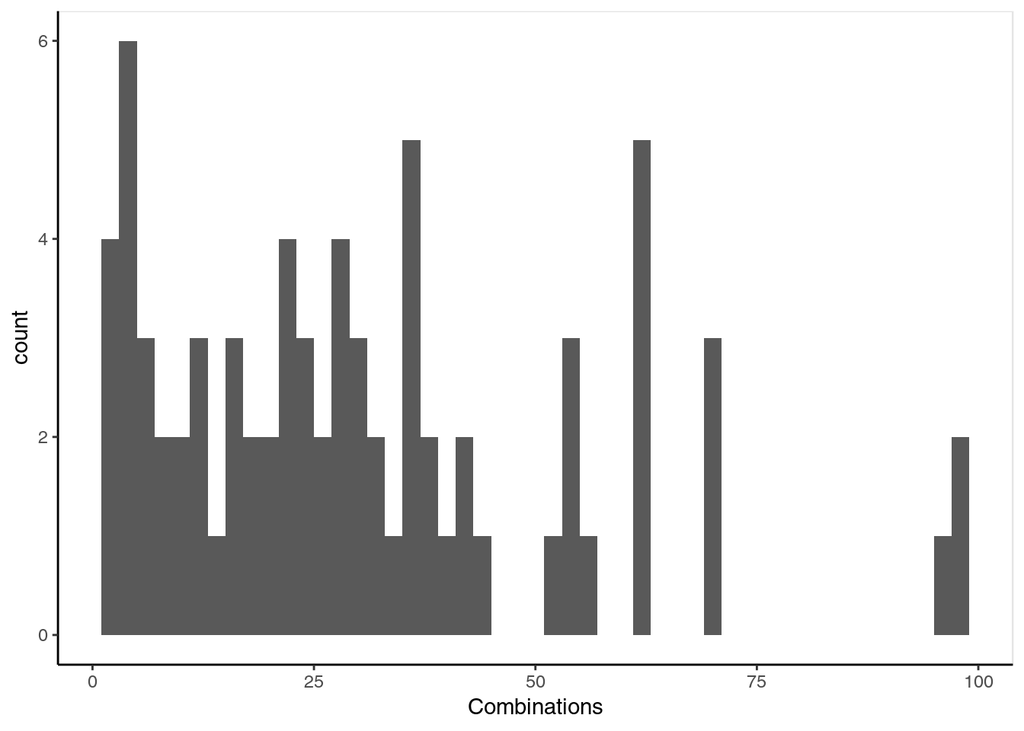

## Combinations by condition

### Total combos

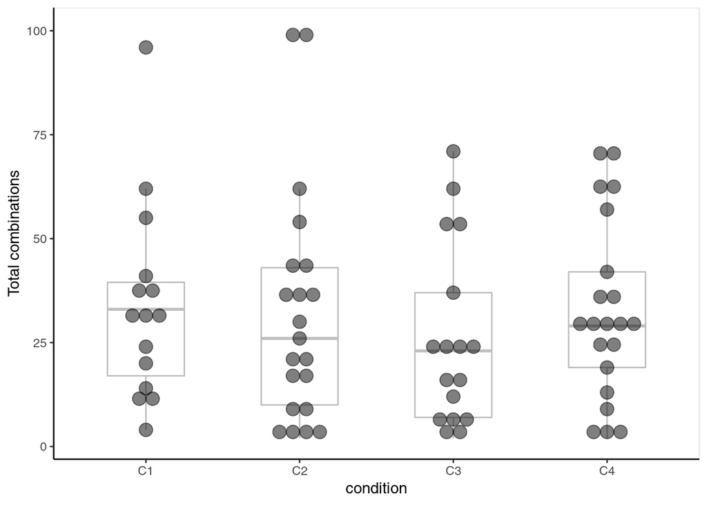

### Combos after success

How much do kids keep trying more combos even when they were successful?

**Note**: 20 children were unsuccessful.

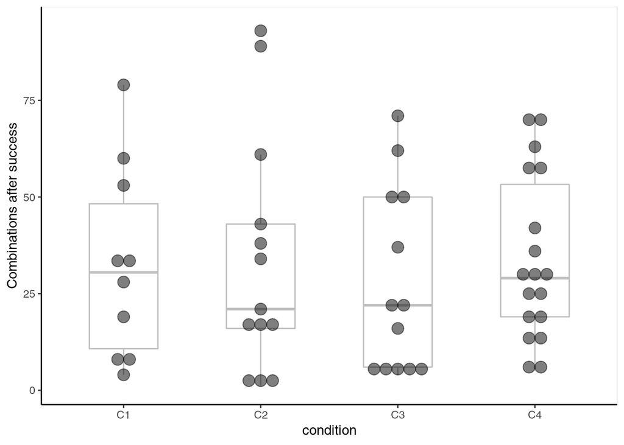

### Combos until success

Excluding unsuccessful children (`20` / `74`)

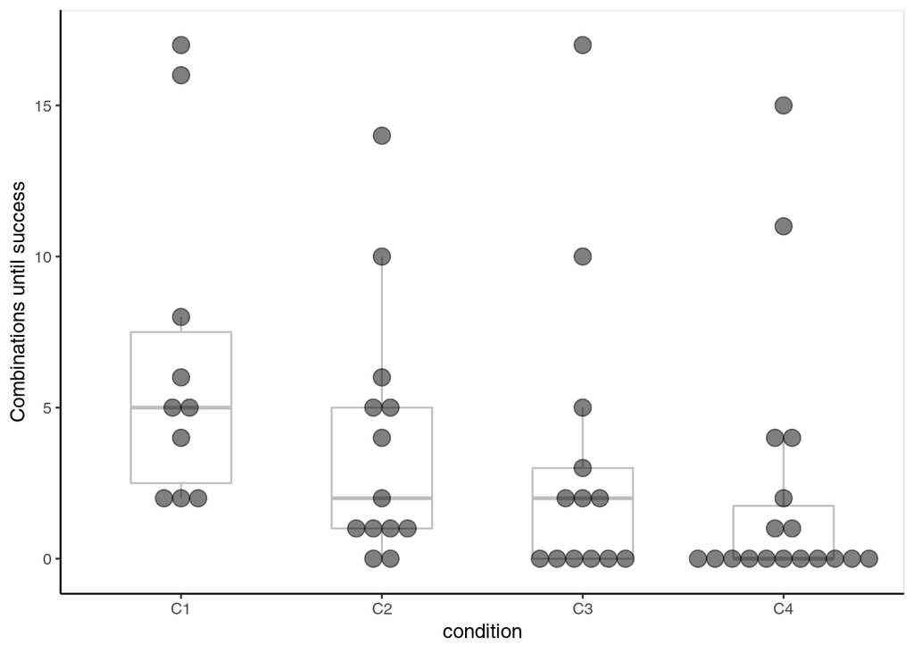

## Combinations by condition and age

Add age as a predictor, otherwise same numbers.

### Total combos

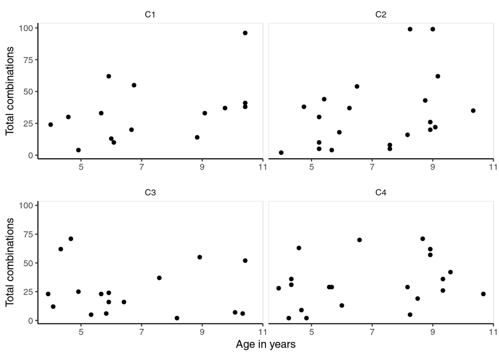

### Combos after success

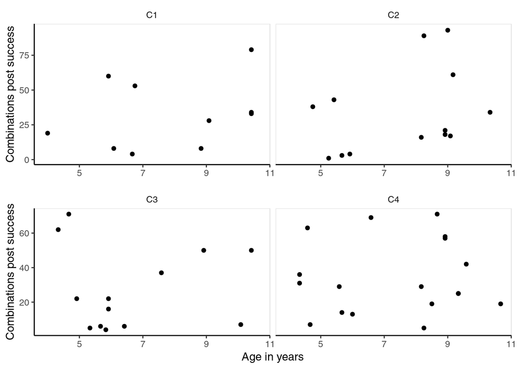

### Combos until success

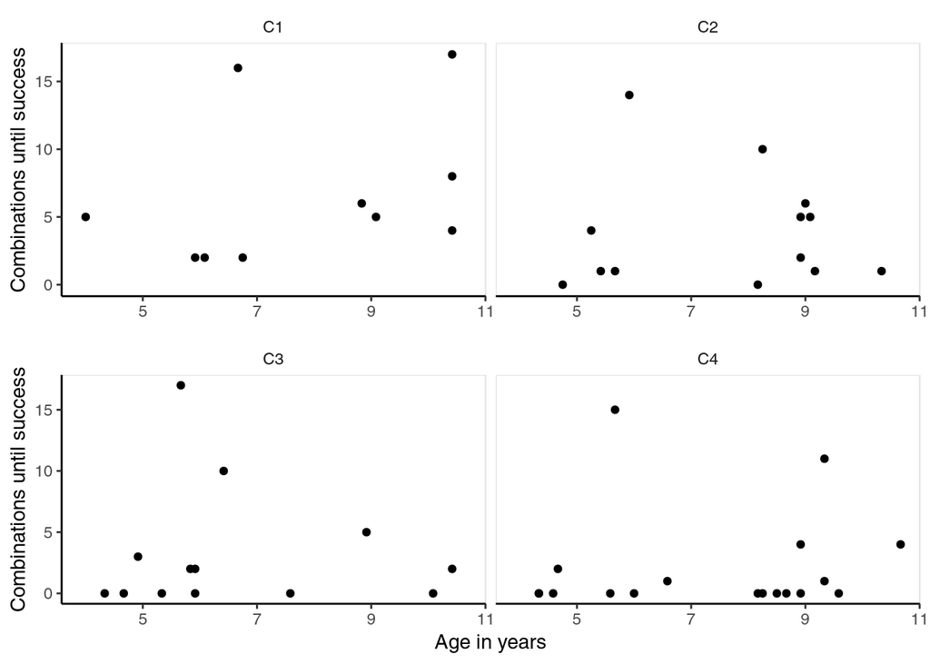

## Combinations before vs. after success

This plot combines the counts of combinations before and after success. The large points show after how many combinations children were successful, and the spans until the small points show their post-success exploration. It reflects information already given above, but puts combos-to-success and combos-upon-success into context.

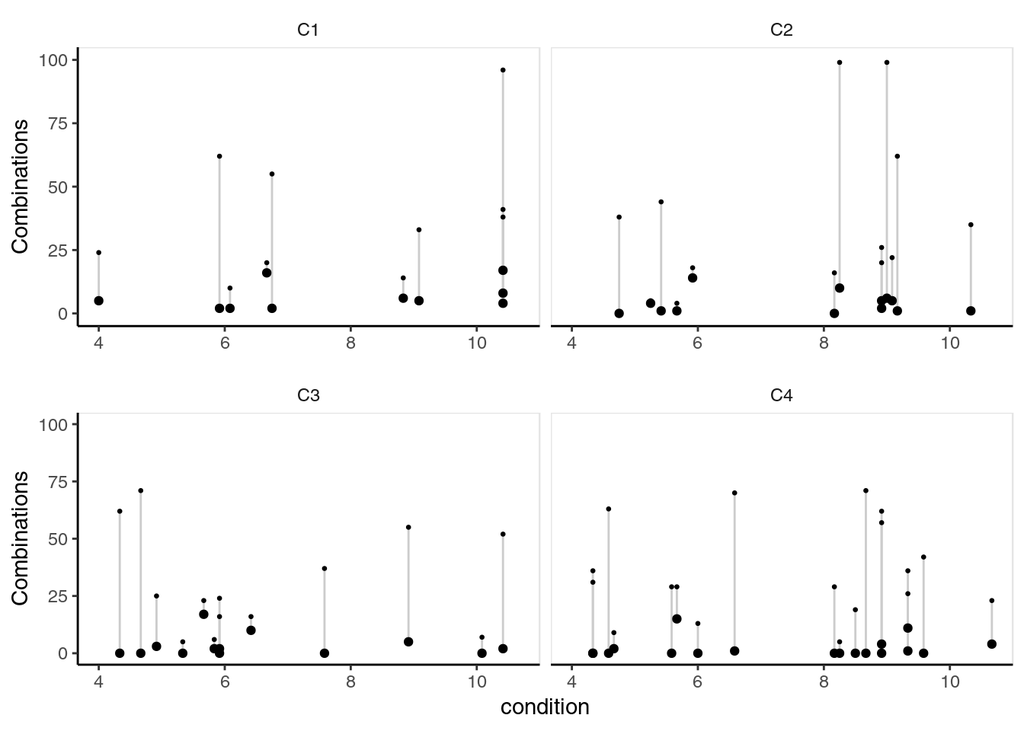

To sum up, the counts of non-unique button presses and combinations of button presses do not suggest any positive effect upon further exploration when the instruction includes an epistemic qualifier by the adult (condition C3). All I can see is that it takes children longer to find the target in C1, probably because they get no hints about likely combinations.

## Time measures by condition

### Time until first look away

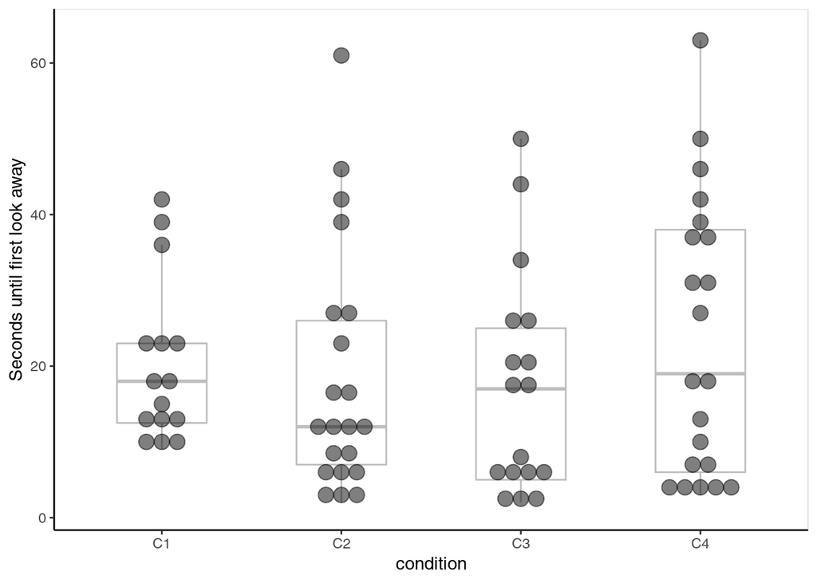

### Time until first inactive for 3 seconds

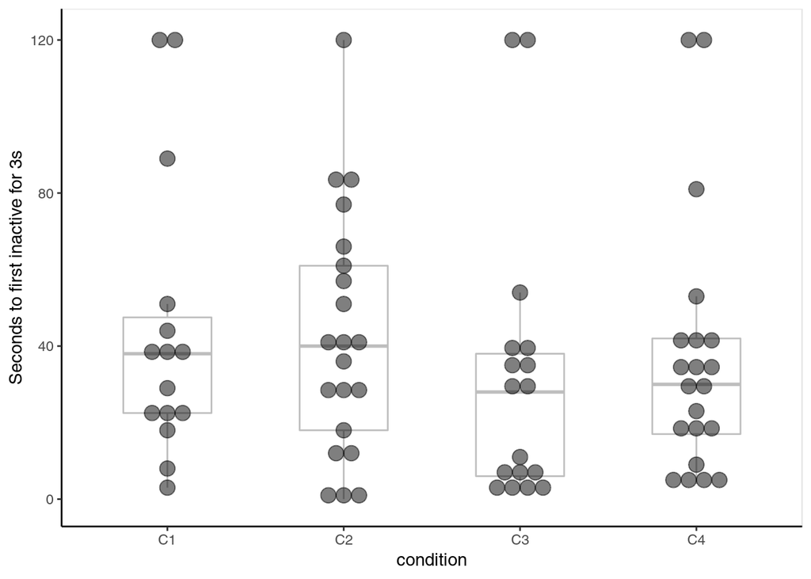

## Time measures by condition and age

### Time until first look away

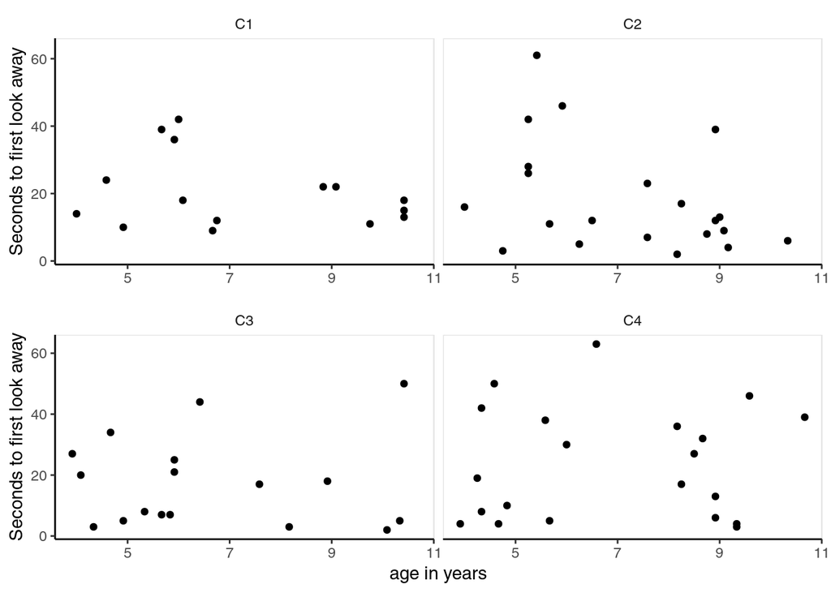

### Time until first inactive for 3 seconds

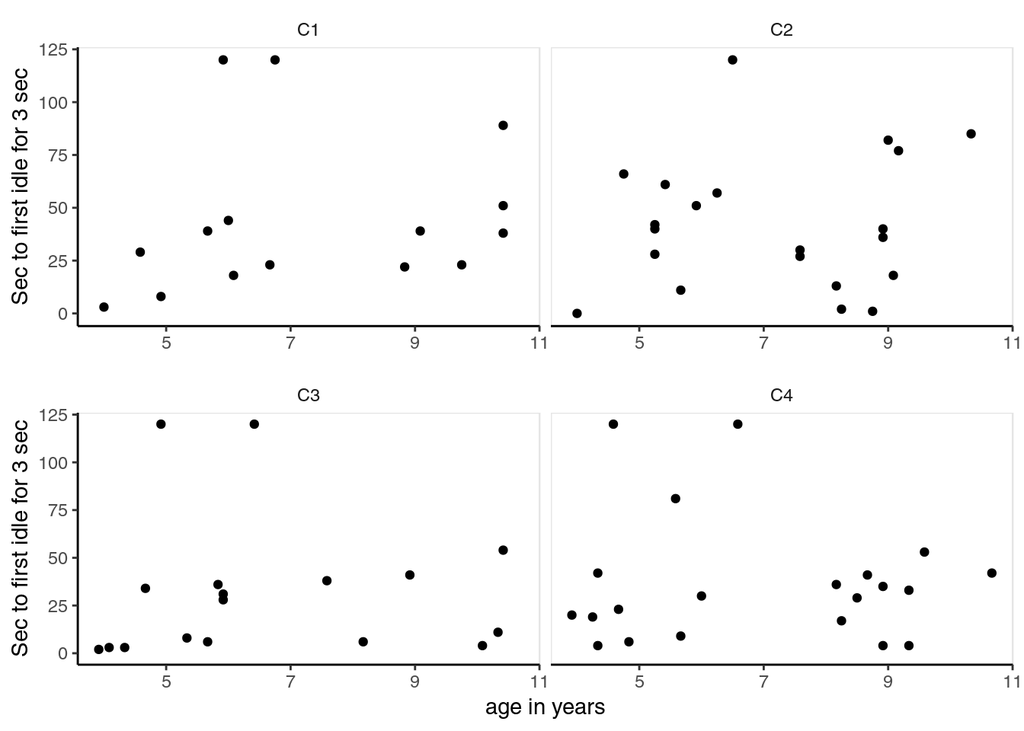

# Models to predict behavior

## Predicting total combos

Total number of combinations (C) as a function of condition and age:

$$\begin{align}
C_i &\sim Poisson(\lambda_i) \\
log(\lambda_i) &= \alpha_{Cond[i]} + \beta A \cdot Age_i + \beta_{Cond[i]} Age_i \\
\alpha_{Cond[i]} &\sim Normal(2, 2) && \text{per-condition intercept} \\
\beta A &\sim Normal(0, 0.5) && \text{age main effect}\\
\beta_{Cond[i]} &\sim Normal(0, 0.5) && \text{per-condition age effect}
\end{align}$$

**Diagnostic**: Check trace plots to see if the MCMC process went fine:

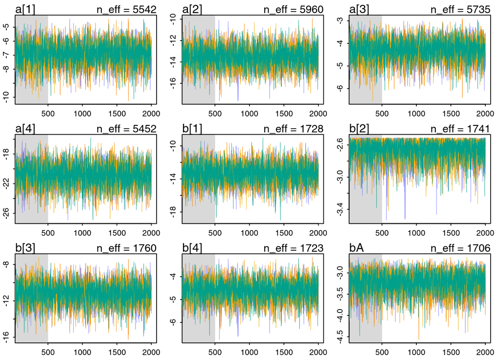

```r
traceplot(m1)
```

Chains look healthy, i.e., the technical sampling or fitting process has been unproblematic.

### Prior prediction check

Check priors: Have we initialized the MCMC process with reasonable assumptions, i.e. with predictions that allow all plausible values? Sample a bunch of random predictions from the priors of the model:

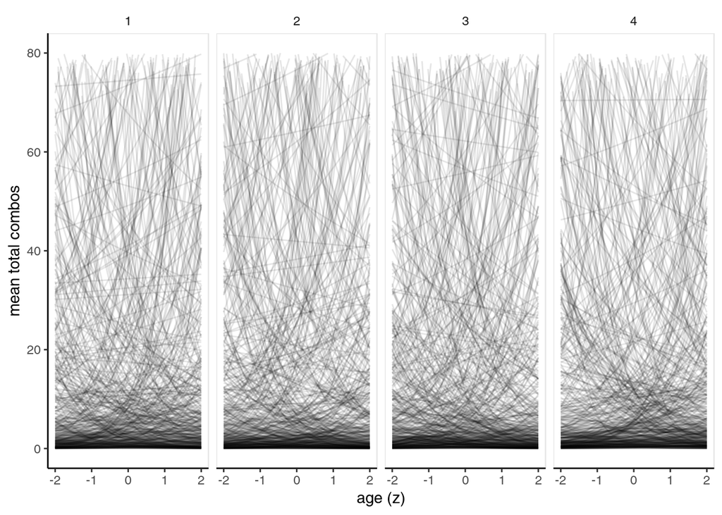

Looks like all plausible values (and some more) were within the model’s prior expectations.

### Posterior predictions

Parameter values are hard to interpret in GLMs, so let’s use them for predictions on the outcome scale instead. How have the data informed our predictions for the mean total combinations (the lambda in the Poisson model) and for plausible actual measurements?

- **lines and blue ribbon**: estimate and 95% ci of the mean ($\lambda$) number of combinations
- **grey ribbon**: 95% ci of predicted number of combinations

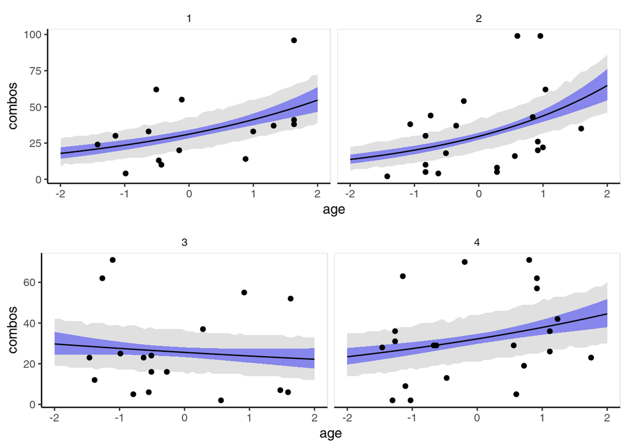

Our data are overdispersed relative to a Poisson model. So there are other forces apart from the Poisson process that influence how many total (non-unique) button presses children perform. Noise comes to mind. For the variable of total button presses, this is the best model I can think of right now, given the measurements that we have.

### Model comparison to a simpler model

… without condition. See if the difference in fit is large. Model structure:

$$\begin{align}
C_i &\sim Poisson(\lambda_i) \\
log(\lambda_i) &= \alpha + \beta Age_i \\
\alpha &\sim Normal(2,2) \\
\beta &\sim Normal(0, 0.5)
\end{align}$$

Check chains:

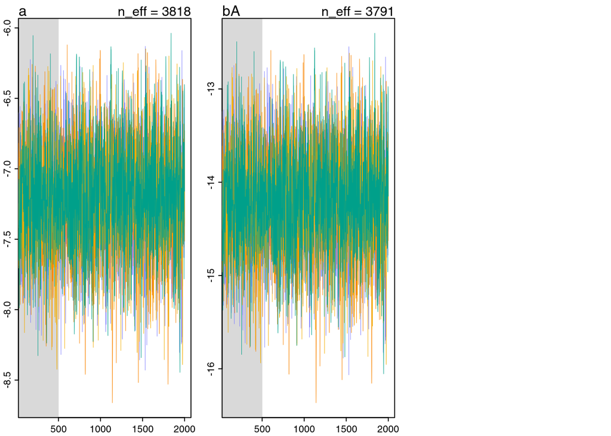

Posterior predictions:

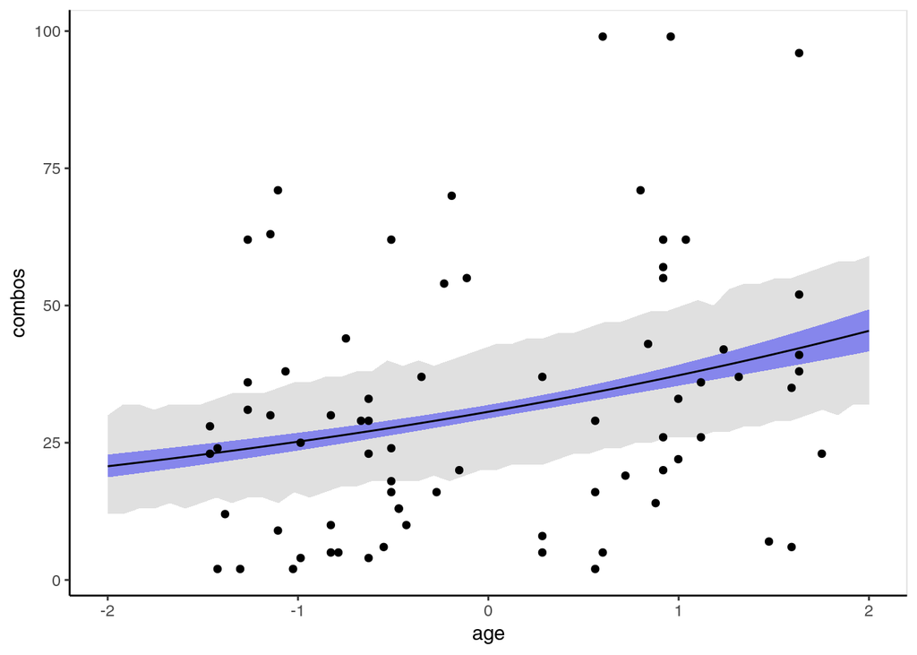

Model comparison between `m1` with condition factor and `m2` without it:

```r
compare(m1, m2)
```

```
##        WAIC     pWAIC    dWAIC       weight       SE      dSE
## m2 1602.769  31.41885  0.00000 1.000000e+00 162.9703       NA
## m1 1640.611 119.33037 37.84156 6.064702e-09 144.1777 72.05979
```

The WAIC (a measure that estimates how good the out-of-sample predictions of a model are) is lower (better) for the model without the condition predictor. All Akaike weight (4th column) is assigned to the simpler model. This suggests that the model *without* condition in it makes better out-of-sample predictions.

In other words, if we predict total combinations from age and condition, we can as well leave away condition.

## The other dependent variables

Now in fast-forward, look at the same pairs of models with the same predictors, but using the other outcome variables, *combinations until success* and *combinations after success*.

**combinations until success**:

```
##                   WAIC    pWAIC    dWAIC       weight       SE      dSE
## m2_preSuccess 538.9488 12.97243  0.00000 0.9994809629 76.99465       NA
## m1_preSuccess 554.0748 44.46743 15.12603 0.0005190371 87.05508 30.21296
```

**combinations after success**:

```
##                    WAIC     pWAIC    dWAIC      weight       SE      dSE
## m2_postSuccess 1279.667  34.72425  0.00000 1.00000e+00 127.8038       NA
## m1_postSuccess 1367.226 133.41625 87.55927 9.69944e-20 118.6621 49.14881
```

The same pattern repeats for the other two measurement variables. Out-of-sample prediction is better without the condition predictor.

Note that as one would expect, the deviance (the “badness of fit”) is lower with the models that contain condition as predictor:

```
##       m1       m2
## 1401.950 1539.932
```

```
## m1_preSuccess m2_preSuccess
##      465.1400      513.0039
```

```
## m1_postSuccess m2_postSuccess
##       1100.393       1210.218
```